# 사건 파일 #아구스 사망사건

Author

JW&SW

## 🕵️ Stage5 쓰레기의 원산지로

**현장 조사 기록:**

- 이름: 아구스
- 직업: 석회석 가마 근로자
- 특징:
- 가족의 증언에 따르면 기침이 잦았음, 동료가 병원에 방문할 것을 권유하였으나 ’피곤해서 그런 것’이라며 넘겼다고 함.
- 자와자와 마을의 공기는 매우 탁함.
- 아구스씨의 가마 공장 창고에는 쓰레기가 가득함.
- 자와자와 마을에서는 쓰레기를 태워서 공장을 가동함.
- 마을 사람들이 쓰레기를 사는 업체가 있음.
- **NEW**🔎 선진국에서 쓰레기가 불법적으로 수출되고 있음.

### 🏠 **금고 안 서류**

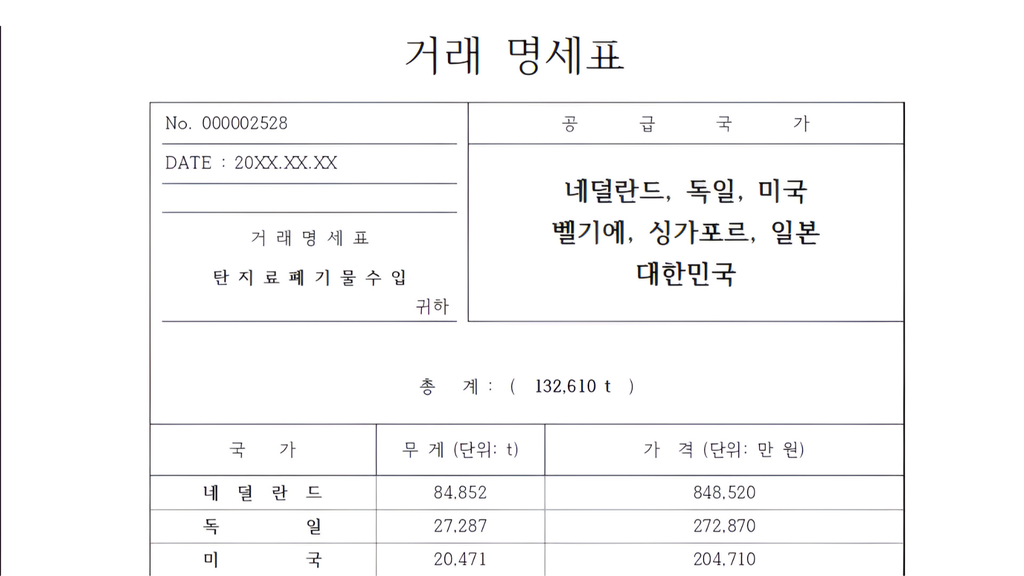

이건… 거래명세서잖아?

이런 국가에서 쓰레기를 불법적으로 수출했군.

못 되먹은 선진국 놈들…!

선진국에도 가 보는 게 좋을 것 같은데…

(수입 업체를 나오다가 정박된 쓰레기 화물선을 발견한다.)

저 화물선을 몰래 타고 가면 쓰레기를 수출한 국가로 갈 수 있을거야.

그렇다면 국제탐정기구에 사건 현황을 보고하고, 도착지의 정보를 부탁해야겠군.

### 🛶**쓰레기 화물선**

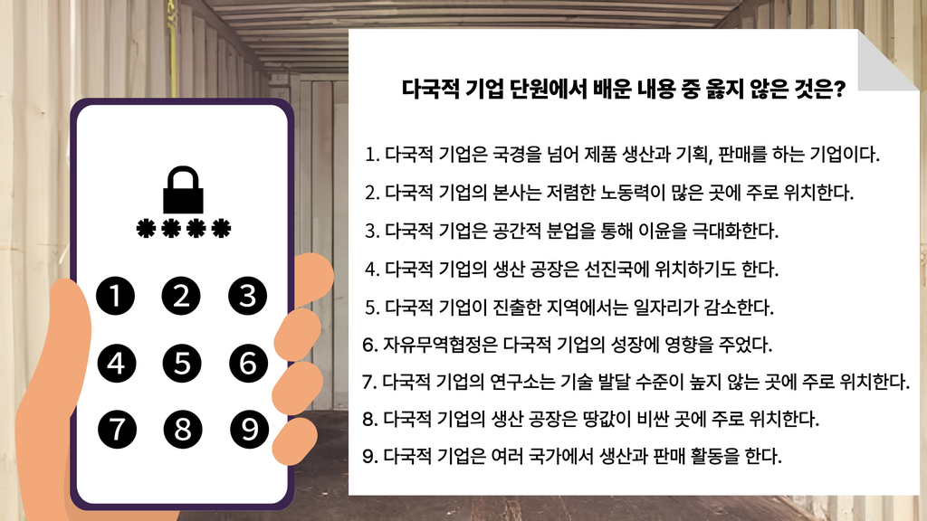

(휴대전화가 울린다.)

탐정들이란…항상 이런 식이지!

꼭 문제를 풀어야만 파일을 받을 수 있는거야? 한시가 급한데…

### ❓ 문제

**파일을 열기위한 비밀번호를 찾아라.**  
(단, 번호는 낮은 숫자부터 차례대로, 쉼표나 공백 없이 적어야한다.)